# Spotify Analysis by Don Nguyen

This analysis will look at a data set pulled from Spotify API, using Python. The data contains 1000 songs which I prefer and 1000 songs from various genres that are not preferred. The Spotify allows access to song data such as “acousticness”, “danceability”, and “energy”. More information about these features can be found on [Spotify’s documentation](https://developer.spotify.com/web-api/get-audio-features/).

# Univariate Plots Section

The first task is to look at the data from a broad overview. Shown below is a summary of the features in songs that are preferred and songs that are not preferred.

```
##   acousticness        danceability     duration_ms         energy
##  Min.   :0.0000089   Min.   :0.0692   Min.   : 93360   Min.   :0.0219
##  1st Qu.:0.0193750   1st Qu.:0.4417   1st Qu.:201887   1st Qu.:0.4960
##  Median :0.1250000   Median :0.5390   Median :234492   Median :0.6620
##  Mean   :0.2748134   Mean   :0.5364   Mean   :242448   Mean   :0.6366
##  3rd Qu.:0.5012500   3rd Qu.:0.6392   3rd Qu.:273856   3rd Qu.:0.8000
##  Max.   :0.9930000   Max.   :0.9570   Max.   :597933   Max.   :0.9950
##  instrumentalness         key            liveness         loudness
##  Min.   :0.0000000   Min.   : 0.000   Min.   :0.0295   Min.   :-26.439
##  1st Qu.:0.0000339   1st Qu.: 2.000   1st Qu.:0.1000   1st Qu.: -8.950
##  Median :0.0040950   Median : 5.000   Median :0.1240   Median : -7.030
##  Mean   :0.1405574   Mean   : 5.034   Mean   :0.1835   Mean   : -7.580
##  3rd Qu.:0.1512500   3rd Qu.: 8.250   3rd Qu.:0.2215   3rd Qu.: -5.529
##  Max.   :0.9650000   Max.   :11.000   Max.   :0.8870   Max.   :  4.235
##       mode        speechiness          tempo        time_signature
##  Min.   :0.000   Min.   :0.02260   Min.   : 59.63   Min.   :1.000
##  1st Qu.:0.000   1st Qu.:0.03240   1st Qu.: 99.02   1st Qu.:4.000
##  Median :1.000   Median :0.04000   Median :118.30   Median :4.000
##  Mean   :0.702   Mean   :0.06136   Mean   :120.73   Mean   :3.922
##  3rd Qu.:1.000   3rd Qu.:0.05713   3rd Qu.:138.09   3rd Qu.:4.000
##  Max.   :1.000   Max.   :0.49700   Max.   :219.33   Max.   :5.000
##     valence       like.
##  Min.   :0.0345   no :   0
##  1st Qu.:0.2620   yes:1000
##  Median :0.4305
##  Mean   :0.4497
##  3rd Qu.:0.6182
##  Max.   :0.9830
```

```
##   acousticness        danceability     duration_ms         energy
##  Min.   :0.0000027   Min.   :0.1300   Min.   : 47227   Min.   :0.1490
##  1st Qu.:0.0020475   1st Qu.:0.4657   1st Qu.:188170   1st Qu.:0.6800
##  Median :0.0297500   Median :0.5715   Median :211213   Median :0.8160
##  Mean   :0.1176619   Mean   :0.5695   Mean   :221778   Mean   :0.7718
##  3rd Qu.:0.1460000   3rd Qu.:0.6803   3rd Qu.:239063   3rd Qu.:0.9093
##  Max.   :0.9370000   Max.   :0.9430   Max.   :917920   Max.   :0.9980
##  instrumentalness         key            liveness          loudness
##  Min.   :0.0000000   Min.   : 0.000   Min.   :0.01990   Min.   :-19.846
##  1st Qu.:0.0000000   1st Qu.: 2.000   1st Qu.:0.09535   1st Qu.: -7.015
##  Median :0.0000058   Median : 6.000   Median :0.14000   Median : -5.308
##  Mean   :0.0502877   Mean   : 5.312   Mean   :0.18934   Mean   : -5.815
##  3rd Qu.:0.0016575   3rd Qu.: 8.000   3rd Qu.:0.25825   3rd Qu.: -4.148
##  Max.   :0.9580000   Max.   :11.000   Max.   :0.95200   Max.   : -0.681
##       mode        speechiness          tempo        time_signature
##  Min.   :0.000   Min.   :0.02320   Min.   : 69.43   Min.   :1.000
##  1st Qu.:0.000   1st Qu.:0.03880   1st Qu.:103.39   1st Qu.:4.000
##  Median :1.000   Median :0.05700   Median :124.98   Median :4.000
##  Mean   :0.653   Mean   :0.08196   Mean   :126.10   Mean   :3.961
##  3rd Qu.:1.000   3rd Qu.:0.09420   3rd Qu.:145.29   3rd Qu.:4.000
##  Max.   :1.000   Max.   :0.50800   Max.   :217.54   Max.   :5.000
##     valence       like.
##  Min.   :0.0293   no :1000
##  1st Qu.:0.3160   yes:   0
##  Median :0.4975
##  Mean   :0.5013
##  3rd Qu.:0.6850
##  Max.   :0.9810
```

By plotting histograms of each feature, the distributions of the data can be explored. Each feature’s distribution was compared between preferred songs and songs that were not preferred.

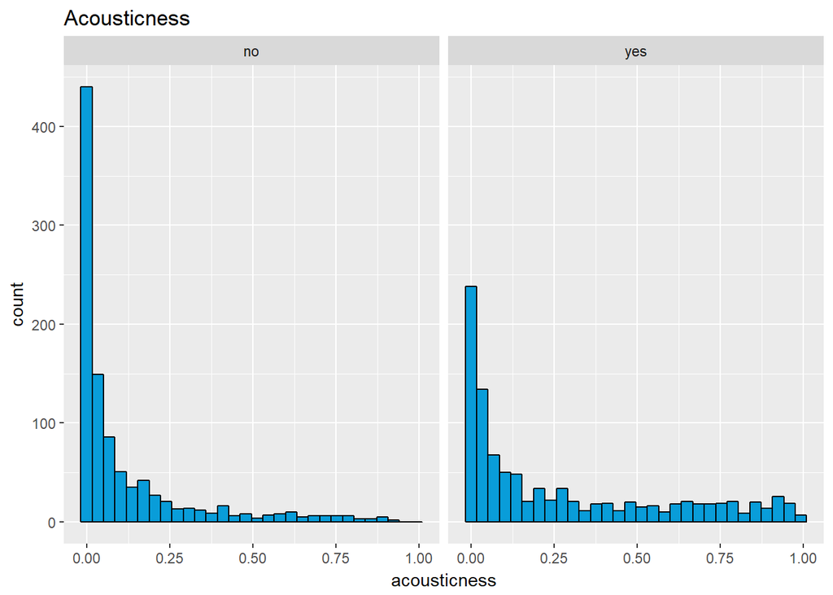

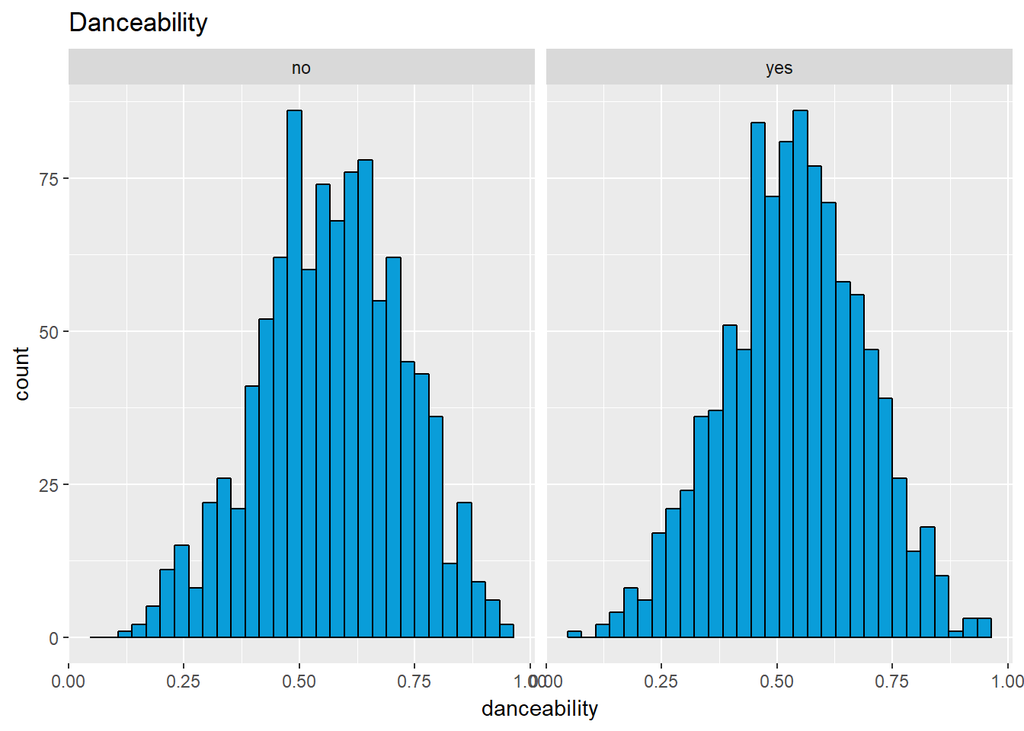

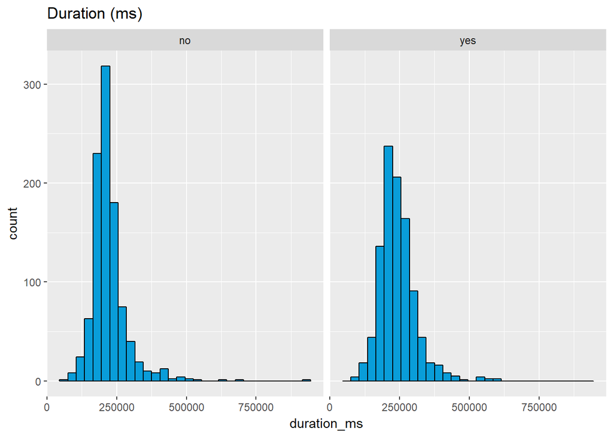

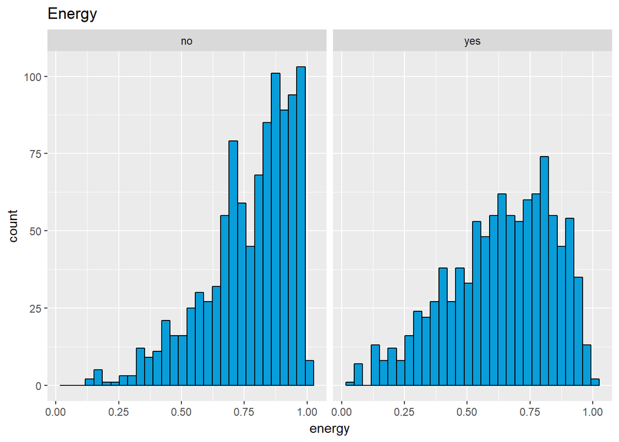

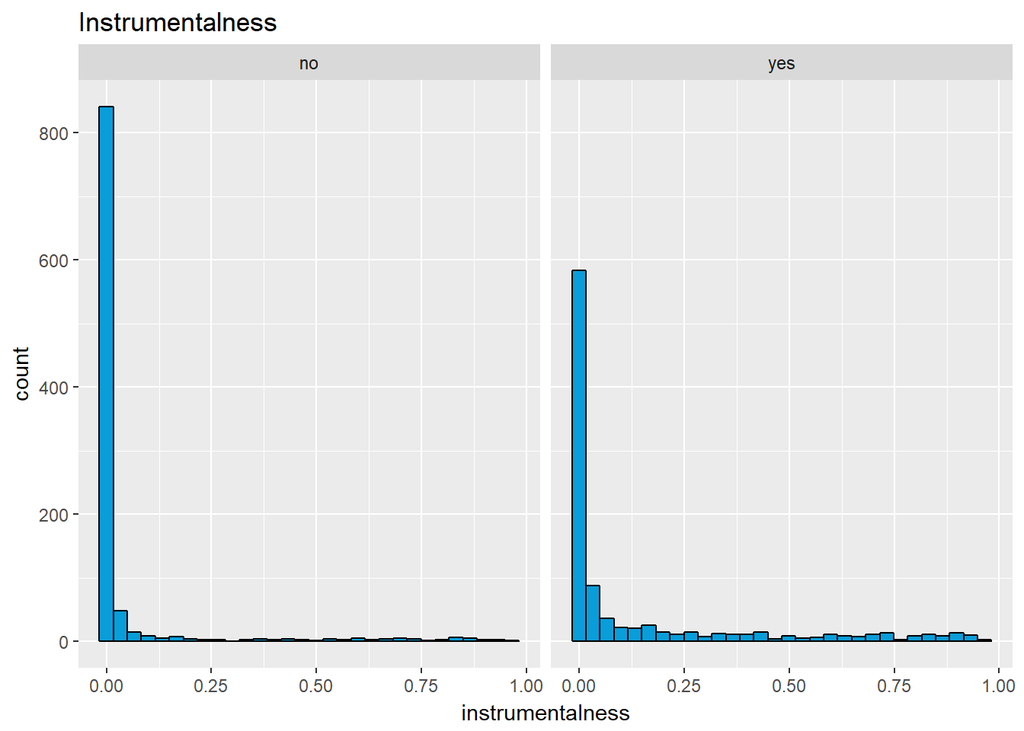

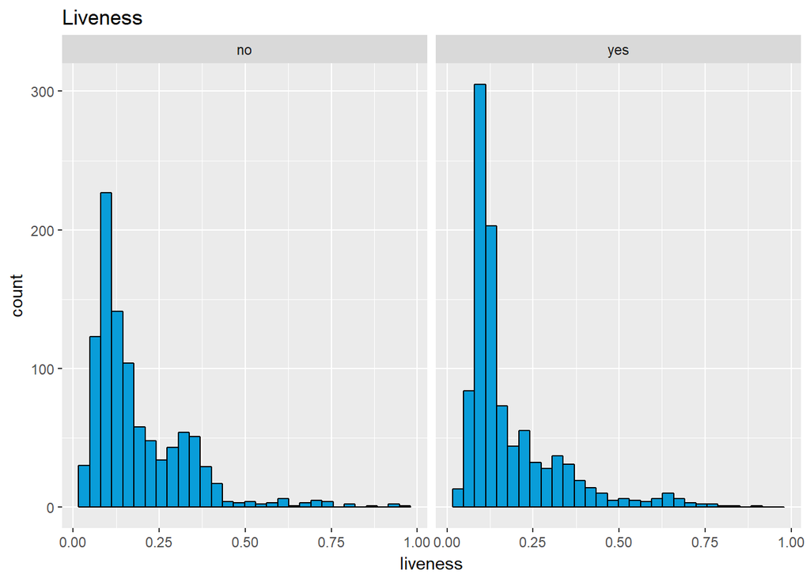

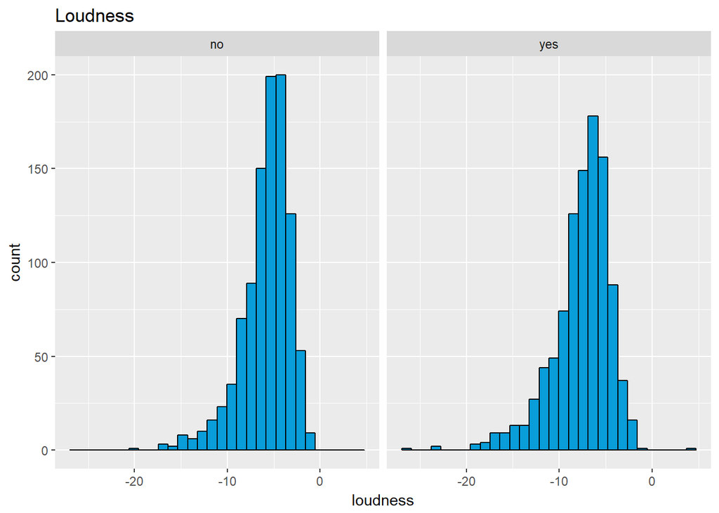

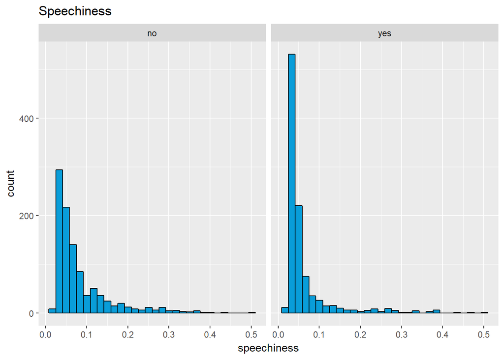

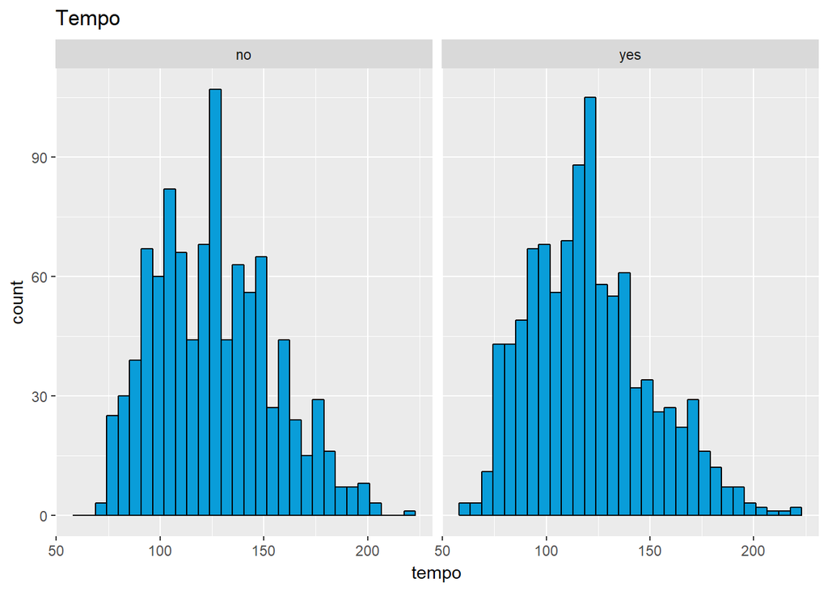

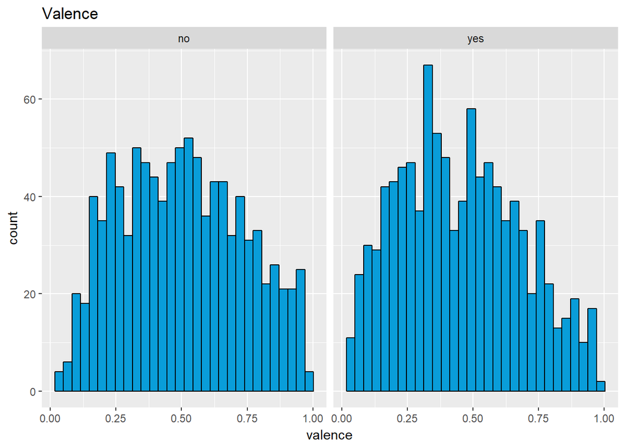

A similar analysis can be done by creating box plots of each variable. Box plots give a better visual comparison of the differences of means between preferred songs and songs that are not preferred.

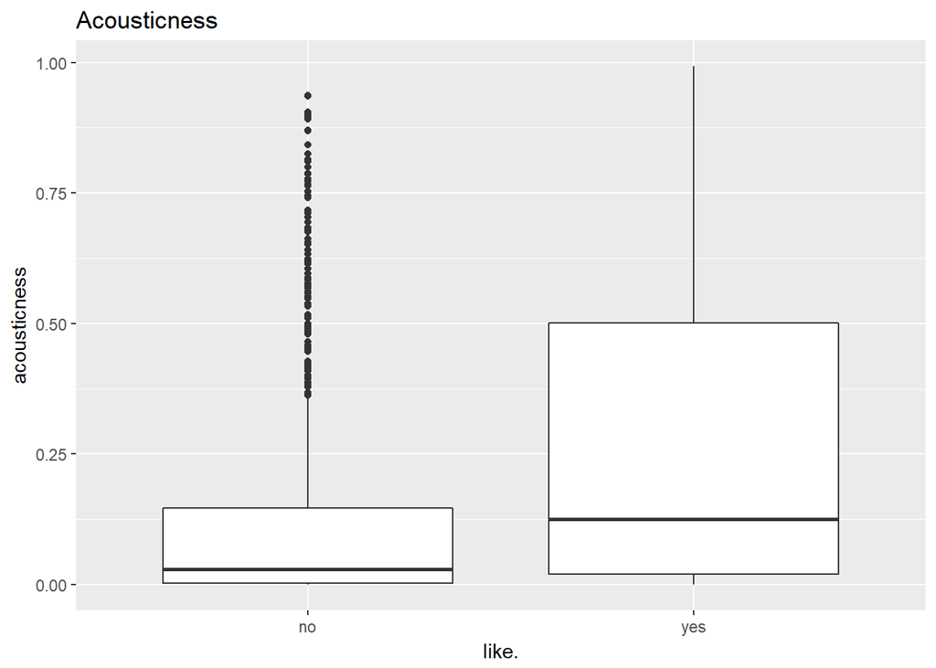

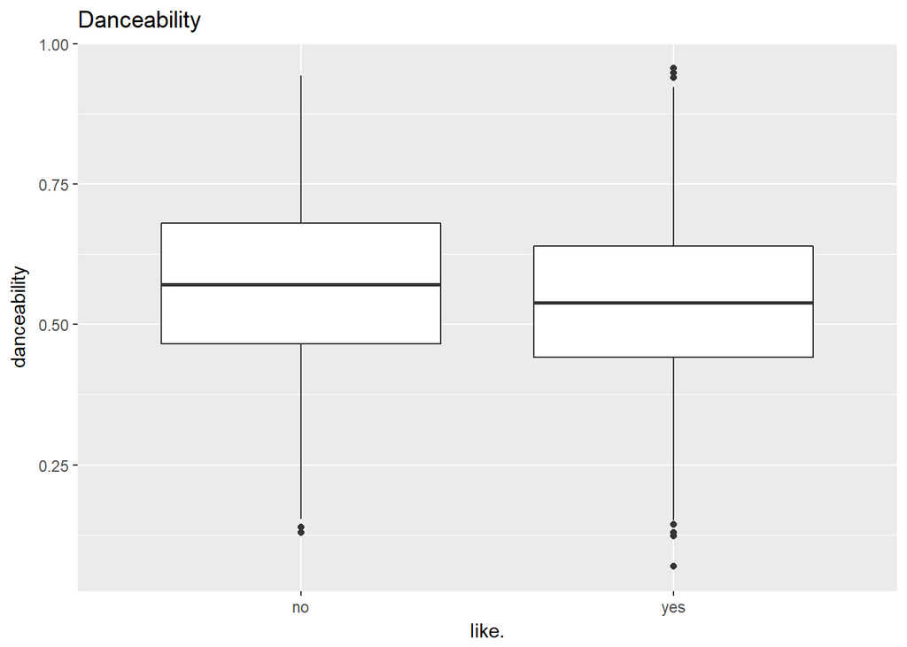

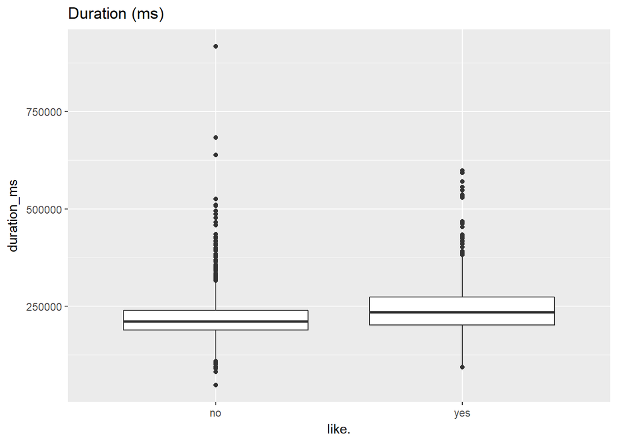

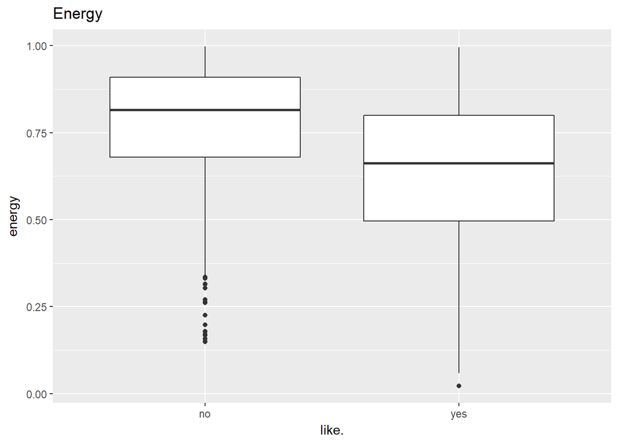

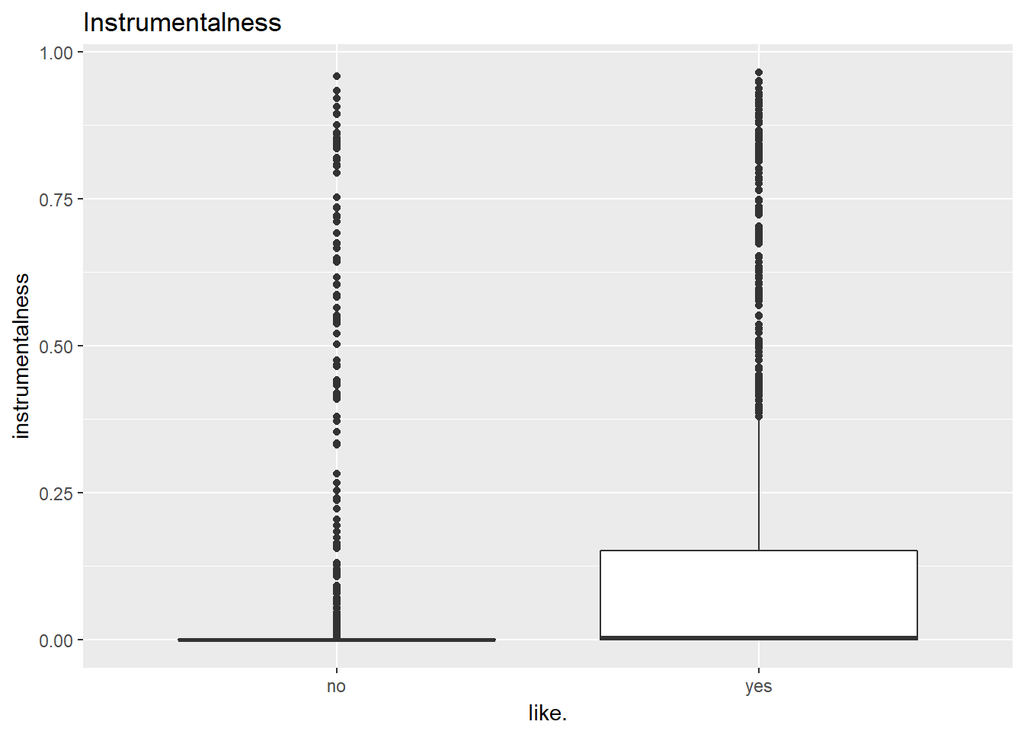

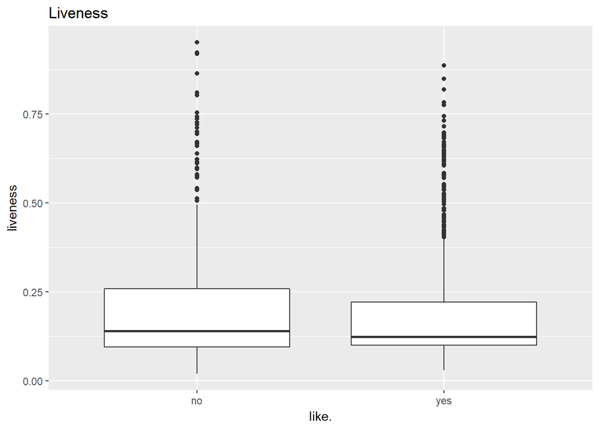

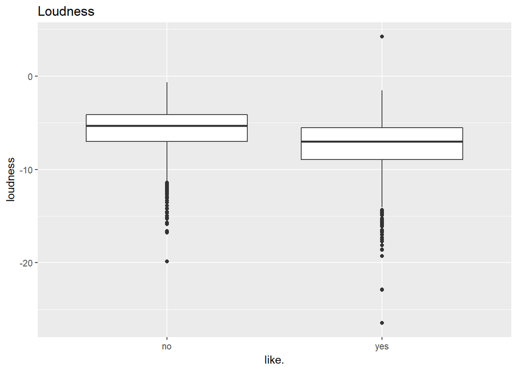

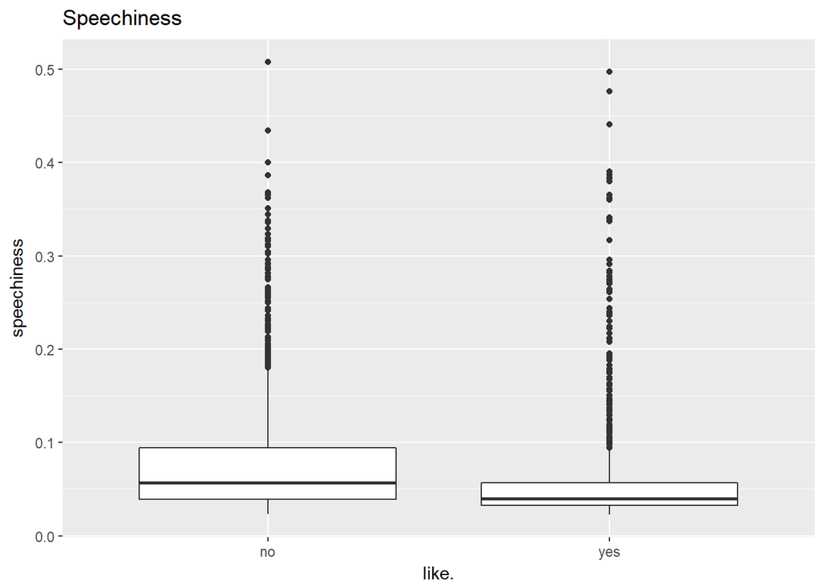

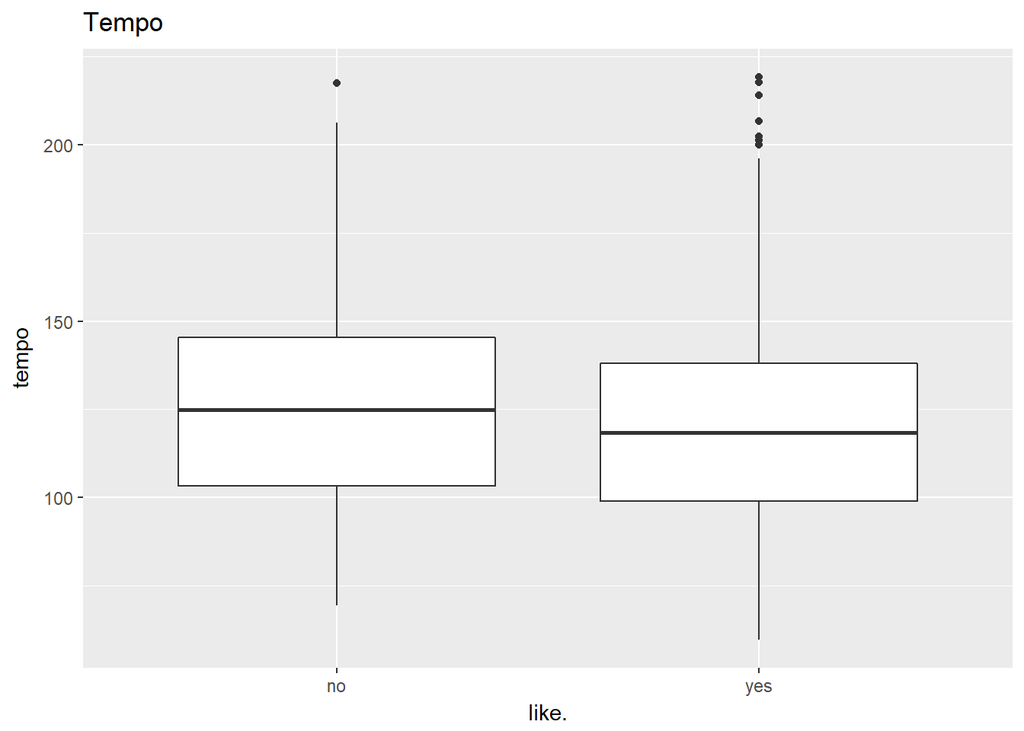

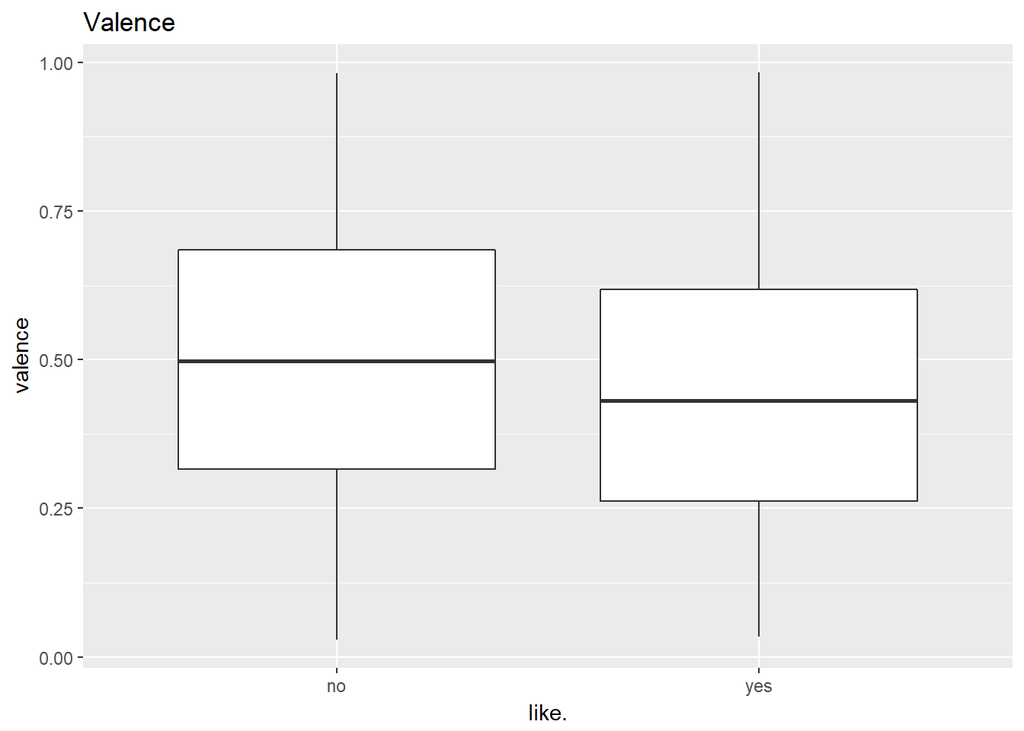

Several t-tests can be computed for the features to quantify the difference in means, assuming the data follows a normal distribution.

```
##
##  Welch Two Sample t-test
##
## data:  like$instrumentalness and dislike$instrumentalness
## t = 9.3976, df = 1732.1, p-value < 2.2e-16
## alternative hypothesis: true difference in means is not equal to 0
## 99 percent confidence interval:
##  0.06549993 0.11503938
## sample estimates:
##  mean of x  mean of y
## 0.14055739 0.05028774
```

```
##
##  Welch Two Sample t-test
##
## data:  like$energy and dislike$energy
## t = -15.744, df = 1935.4, p-value < 2.2e-16
## alternative hypothesis: true difference in means is not equal to 0
## 99 percent confidence interval:
##  -0.1573993 -0.1130991
## sample estimates:
## mean of x mean of y
## 0.6365798 0.7718290
```

```
##
##  Welch Two Sample t-test
##
## data:  like$acousticness and dislike$acousticness
## t = 13.659, df = 1673.6, p-value < 2.2e-16
## alternative hypothesis: true difference in means is not equal to 0
## 99 percent confidence interval:
##  0.1274818 0.1868212
## sample estimates:
## mean of x mean of y
## 0.2748134 0.1176619
```

```
##
##  Welch Two Sample t-test
##
## data:  like$danceability and dislike$danceability
## t = -4.8639, df = 1996.7, p-value = 1.241e-06
## alternative hypothesis: true difference in means is not equal to 0
## 99 percent confidence interval:
##  -0.05072685 -0.01557875
## sample estimates:
## mean of x mean of y
## 0.5363852 0.5695380
```

```
##
##  Welch Two Sample t-test
##
## data:  like$tempo and dislike$tempo
## t = -4.2022, df = 1997.6, p-value = 2.759e-05
## alternative hypothesis: true difference in means is not equal to 0
## 99 percent confidence interval:
##  -8.668594 -2.076132
## sample estimates:
## mean of x mean of y
##  120.7264  126.0987
```

```
##
##  Welch Two Sample t-test
##
## data:  like$valence and dislike$valence
## t = -4.9732, df = 1997.7, p-value = 7.147e-07
## alternative hypothesis: true difference in means is not equal to 0
## 99 percent confidence interval:
##  -0.0783907 -0.0248613
## sample estimates:
## mean of x mean of y
## 0.4496938 0.5013198
```

# Univariate Analysis

### What is the structure of your dataset?

The dataset consists of 2000 songs, half of which are songs I categorized as preferring on Spotify, the other half categorized as not preferring. The songs I do not prefer have been pulled from many different genres of music. Each song has 14 features that can be analyzed.

### What is/are the main feature(s) of interest in your dataset?

The main feature to be investigated is the “like.” column, which represents whether or not I have classified the song preferrence on Spotify.

### What other features in the dataset do you think will help support your investigation into your feature(s) of interest?

I will be exploring all other features of the songs as a function of “like.” to find patterns in songs I do and do not enjoy. The features that stand out initally are energy and instrumentalness.

### Did you create any new variables from existing variables in the dataset?

Currently, none of the variables have been created based off existing variables.

### Of the features you investigated, were there any unusual distributions? Did you perform any operations on the data to tidy, adjust, or change the form of the data? If so, why did you do this?

A couple data points needed to be removed prior to loading into R since they had null features. After removing the two songs, the rest of the data came tidy from Spotify. A few features were dropped due to not giving much information to analyze.

The features that stood out to me as having the most difference between songs I liked and disliked were energy, acousticness, and instrumentalness. Songs I prefer tend to have lower energy, and more acousticness than songs I did not prefer. The songs I do not prefer also are clearly not instrumental, whereas songs I prefer have a higher probability of being instrumental.

# Bivariate Plots Section

Scatter plots are created to find and understand relationships between the features.

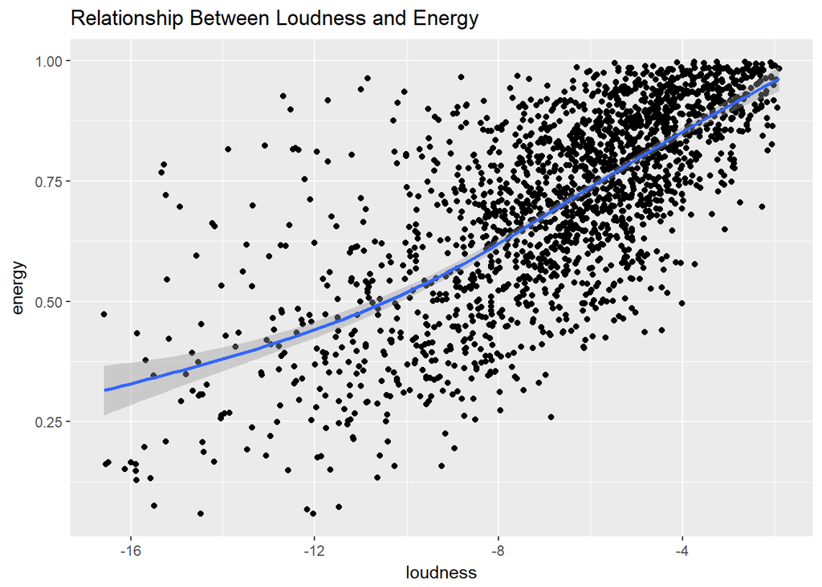

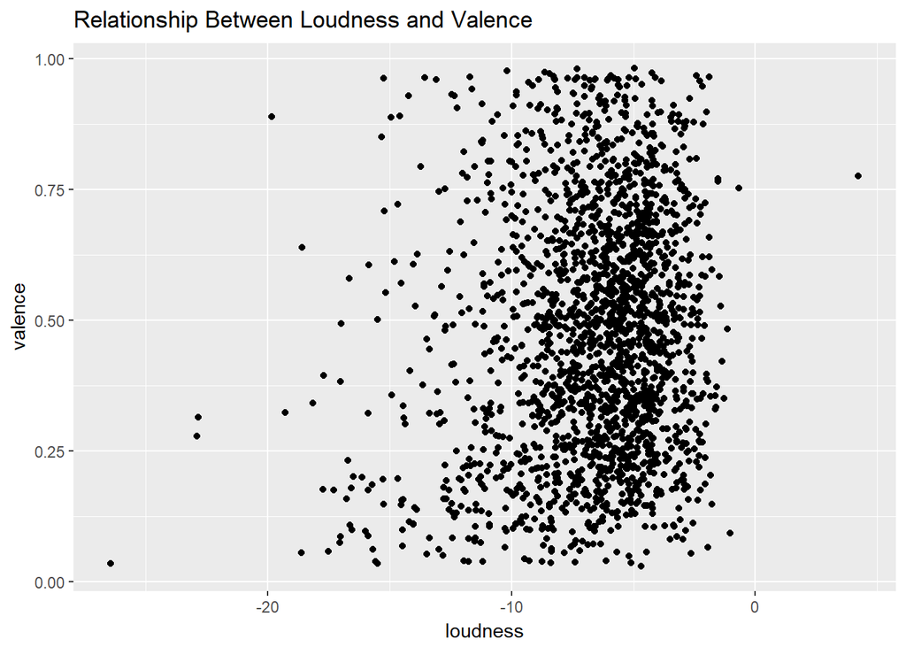

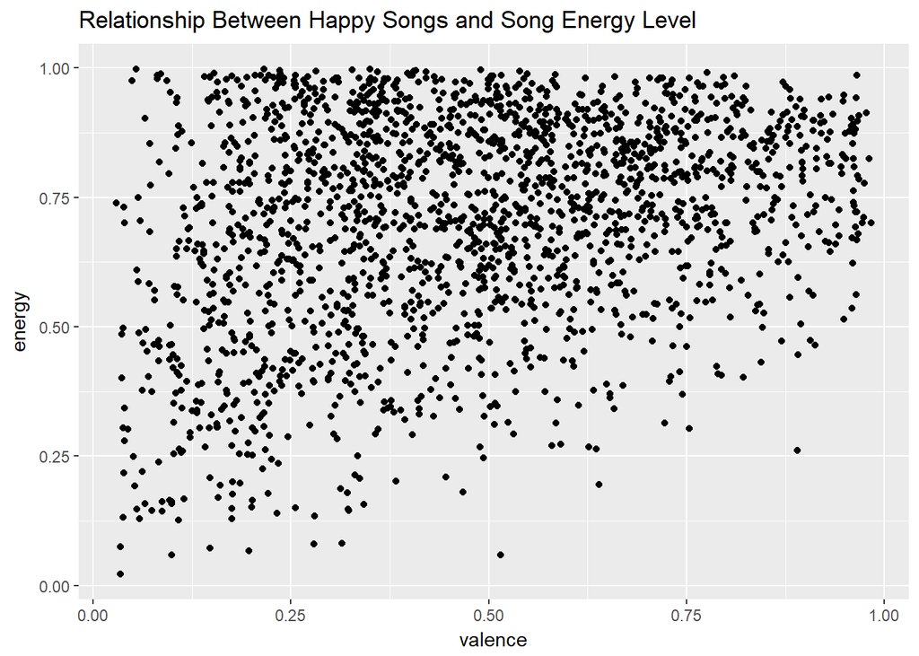

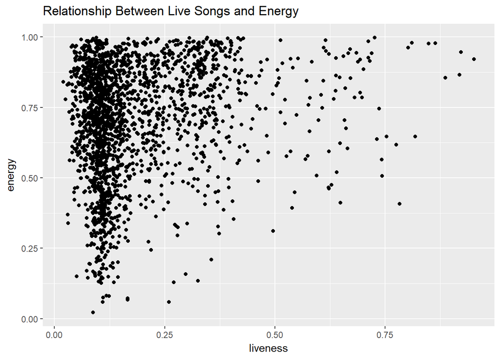

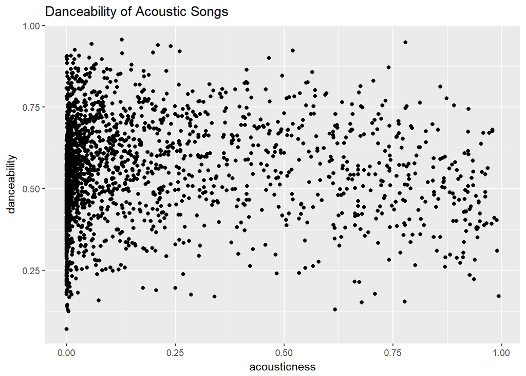

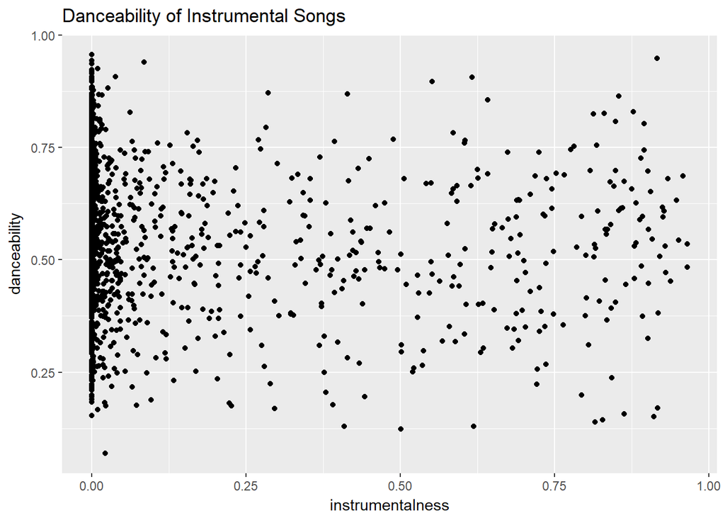

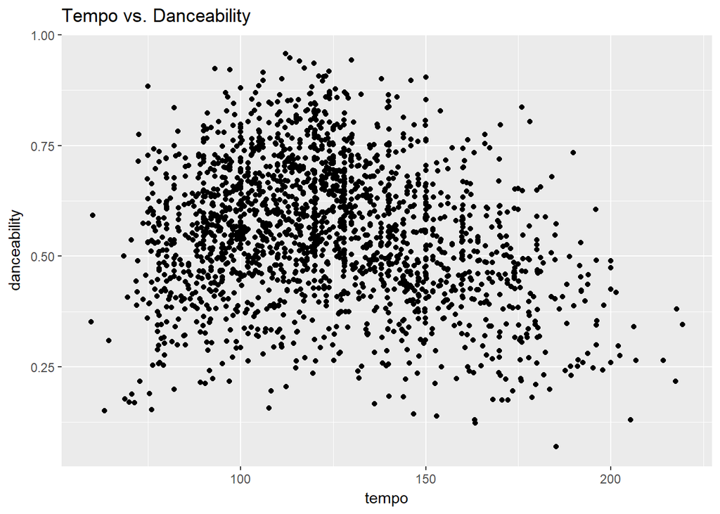

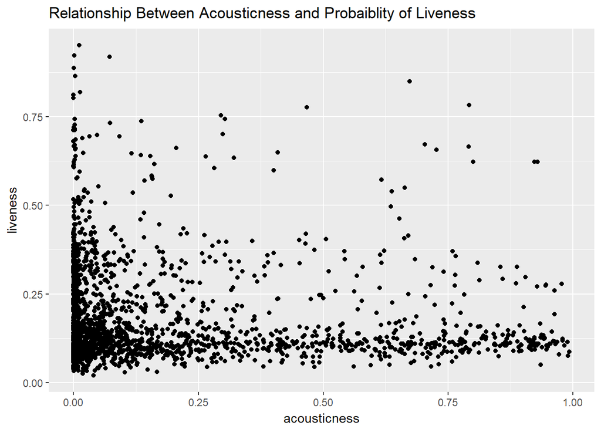

The Pearson’s correlation can be used to quantify trends between features.

```
##
##  Pearson's product-moment correlation
##
## data:  loudness and energy
## t = 48.845, df = 1998, p-value < 2.2e-16
## alternative hypothesis: true correlation is not equal to 0
## 95 percent confidence interval:
##  0.7170783 0.7570734
## sample estimates:
##       cor
## 0.7377225
```

```
##
##  Pearson's product-moment correlation
##
## data:  valence and energy
## t = 13.307, df = 1998, p-value < 2.2e-16
## alternative hypothesis: true correlation is not equal to 0
## 95 percent confidence interval:
##  0.2445527 0.3250906
## sample estimates:
##       cor
## 0.2853252
```

```
##
##  Pearson's product-moment correlation
##
## data:  tempo and danceability
## t = -8.8319, df = 1998, p-value < 2.2e-16
## alternative hypothesis: true correlation is not equal to 0
## 95 percent confidence interval:
##  -0.2356678 -0.1512936
## sample estimates:
##        cor
## -0.1938391
```

# Bivariate Analysis

### Talk about some of the relationships you observed in this part of the investigation. How did the feature(s) of interest vary with other features in the dataset?

There is a clear positive linear relationship between loudness and energy. There seems to be a polynomial relationship between tempo and danceability too. These relationships are not surprising. However, valence did not show a strong correlation with energy nor loudness. The other variables also did not show any strong correlations with each other.

### What was the strongest relationship you found?

Loudness and energy has a strong, positive linear relationship. Energy may be based off of loudness.